# Assignment 4

## Objectives:

- To predict which customer is more likely to purchase the newly introduced travel package.

## Data

**Customer details:**

- CustomerID: Unique customer ID
- ProdTaken: Whether the customer has purchased a package or not (0: No, 1: Yes)
- Age: Age of customer
- TypeofContact: How customer was contacted (Company Invited or Self Inquiry)
- CityTier: City tier depends on the development of a city, population, facilities, and living standards. The categories are ordered i.e. Tier 1 > Tier 2 > Tier 3
- Occupation: Occupation of customer
- Gender: Gender of customer
- NumberOfPersonVisiting: Total number of persons planning to take the trip with the customer
- PreferredPropertyStar: Preferred hotel property rating by customer
- MaritalStatus: Marital status of customer
- NumberOfTrips: Average number of trips in a year by customer
- Passport: The customer has a passport or not (0: No, 1: Yes)
- OwnCar: Whether the customers own a car or not (0: No, 1: Yes)
- NumberOfChildrenVisiting: Total number of children with age less than 5 planning to take the trip with the customer
- Designation: Designation of the customer in the current organization
- MonthlyIncome: Gross monthly income of the customer

**Customer interaction data:**

- PitchSatisfactionScore: Sales pitch satisfaction score
- ProductPitched: Product pitched by the salesperson
- NumberOfFollowups: Total number of follow-ups has been done by the salesperson after the sales pitch
- DurationOfPitch: Duration of the pitch by a salesperson to the customer

### Import Libraries

```python
import warnings
warnings.filterwarnings("ignore")
import numpy as np
import pandas as pd
import matplotlib.pyplot as plt
import seaborn as sns
from sklearn.tree import DecisionTreeRegressor
from sklearn.tree import DecisionTreeClassifier
from sklearn.model_selection import train_test_split
from sklearn.metrics import confusion_matrix, classification_report
from sklearn.metrics import accuracy_score,precision_score,recall_score,f1_score
import scipy.stats as stats
from sklearn import metrics
from sklearn import tree
from sklearn.ensemble import BaggingRegressor,RandomForestRegressor, GradientBoostingRegressor, AdaBoostRegressor, StackingRegressor
from sklearn.linear_model import LogisticRegression
from xgboost import XGBRegressor
from sklearn.ensemble import AdaBoostClassifier, GradientBoostingClassifier, StackingClassifier
from xgboost import XGBClassifier
from sklearn.model_selection import GridSearchCV
from sklearn.ensemble import BaggingClassifier
from sklearn.ensemble import RandomForestClassifier
from sklearn.metrics import roc_auc_score
from sklearn.metrics import r2_score, mean_squared_error, mean_absolute_error
import warnings
```

### Read the dataset

```python
tourism_data = pd.read_excel("Tourism.xlsx",sheet_name=1)
df = tourism_data.copy()
```

### View the dataset

```python
df.head()
```

|  | CustomerID | ProdTaken | Age | TypeofContact | CityTier | DurationOfPitch | Occupation | Gender | NumberOfPersonVisiting | NumberOfFollowups | ProductPitched | PreferredPropertyStar | MaritalStatus | NumberOfTrips | Passport | PitchSatisfactionScore | OwnCar | NumberOfChildrenVisiting | Designation | MonthlyIncome |
| --- | --- | --- | --- | --- | --- | --- | --- | --- | --- | --- | --- | --- | --- | --- | --- | --- | --- | --- | --- | --- |
| 0 | 200000 | 1 | 41.0 | Self Enquiry | 3 | 6.0 | Salaried | Female | 3 | 3.0 | Deluxe | 3.0 | Single | 1.0 | 1 | 2 | 1 | 0.0 | Manager | 20993.0 |
| 1 | 200001 | 0 | 49.0 | Company Invited | 1 | 14.0 | Salaried | Male | 3 | 4.0 | Deluxe | 4.0 | Divorced | 2.0 | 0 | 3 | 1 | 2.0 | Manager | 20130.0 |
| 2 | 200002 | 1 | 37.0 | Self Enquiry | 1 | 8.0 | Free Lancer | Male | 3 | 4.0 | Basic | 3.0 | Single | 7.0 | 1 | 3 | 0 | 0.0 | Executive | 17090.0 |
| 3 | 200003 | 0 | 33.0 | Company Invited | 1 | 9.0 | Salaried | Female | 2 | 3.0 | Basic | 3.0 | Divorced | 2.0 | 1 | 5 | 1 | 1.0 | Executive | 17909.0 |
| 4 | 200004 | 0 | NaN | Self Enquiry | 1 | 8.0 | Small Business | Male | 2 | 3.0 | Basic | 4.0 | Divorced | 1.0 | 0 | 5 | 1 | 0.0 | Executive | 18468.0 |

```python
df.tail()
```

|  | CustomerID | ProdTaken | Age | TypeofContact | CityTier | DurationOfPitch | Occupation | Gender | NumberOfPersonVisiting | NumberOfFollowups | ProductPitched | PreferredPropertyStar | MaritalStatus | NumberOfTrips | Passport | PitchSatisfactionScore | OwnCar | NumberOfChildrenVisiting | Designation | MonthlyIncome |
| --- | --- | --- | --- | --- | --- | --- | --- | --- | --- | --- | --- | --- | --- | --- | --- | --- | --- | --- | --- | --- |
| 4883 | 204883 | 1 | 49.0 | Self Enquiry | 3 | 9.0 | Small Business | Male | 3 | 5.0 | Deluxe | 4.0 | Unmarried | 2.0 | 1 | 1 | 1 | 1.0 | Manager | 26576.0 |
| 4884 | 204884 | 1 | 28.0 | Company Invited | 1 | 31.0 | Salaried | Male | 4 | 5.0 | Basic | 3.0 | Single | 3.0 | 1 | 3 | 1 | 2.0 | Executive | 21212.0 |
| 4885 | 204885 | 1 | 52.0 | Self Enquiry | 3 | 17.0 | Salaried | Female | 4 | 4.0 | Standard | 4.0 | Married | 7.0 | 0 | 1 | 1 | 3.0 | Senior Manager | 31820.0 |
| 4886 | 204886 | 1 | 19.0 | Self Enquiry | 3 | 16.0 | Small Business | Male | 3 | 4.0 | Basic | 3.0 | Single | 3.0 | 0 | 5 | 0 | 2.0 | Executive | 20289.0 |
| 4887 | 204887 | 1 | 36.0 | Self Enquiry | 1 | 14.0 | Salaried | Male | 4 | 4.0 | Basic | 4.0 | Unmarried | 3.0 | 1 | 3 | 1 | 2.0 | Executive | 24041.0 |

- customer ID different then index
- Prodtaken written in true or false as numeric
- Durationofpitch time is unclassified
- MonthlyIncome currency is unclassified

### Check for duplications

```python
df[df.duplicated()].count()
```

```
CustomerID                  0
ProdTaken                   0
Age                         0
TypeofContact               0
CityTier                    0
DurationOfPitch             0
Occupation                  0
Gender                      0
NumberOfPersonVisiting      0
NumberOfFollowups           0
ProductPitched              0
PreferredPropertyStar       0
MaritalStatus               0
NumberOfTrips               0
Passport                    0
PitchSatisfactionScore      0
OwnCar                      0
NumberOfChildrenVisiting    0
Designation                 0
MonthlyIncome               0
dtype: int64
```

### Dropping uneeded columns

Since we have already checked that all values are unique to a customer, CustomerID is useless to us statistically, we will drop it.

```python
df.drop('CustomerID',axis=1,inplace=True)
```

```python
#Checking that it was dropped
df.head()
```

|  | ProdTaken | Age | TypeofContact | CityTier | DurationOfPitch | Occupation | Gender | NumberOfPersonVisiting | NumberOfFollowups | ProductPitched | PreferredPropertyStar | MaritalStatus | NumberOfTrips | Passport | PitchSatisfactionScore | OwnCar | NumberOfChildrenVisiting | Designation | MonthlyIncome |
| --- | --- | --- | --- | --- | --- | --- | --- | --- | --- | --- | --- | --- | --- | --- | --- | --- | --- | --- | --- |
| 0 | 1 | 41.0 | Self Enquiry | 3 | 6.0 | Salaried | Female | 3 | 3.0 | Deluxe | 3.0 | Single | 1.0 | 1 | 2 | 1 | 0.0 | Manager | 20993.0 |
| 1 | 0 | 49.0 | Company Invited | 1 | 14.0 | Salaried | Male | 3 | 4.0 | Deluxe | 4.0 | Divorced | 2.0 | 0 | 3 | 1 | 2.0 | Manager | 20130.0 |
| 2 | 1 | 37.0 | Self Enquiry | 1 | 8.0 | Free Lancer | Male | 3 | 4.0 | Basic | 3.0 | Single | 7.0 | 1 | 3 | 0 | 0.0 | Executive | 17090.0 |
| 3 | 0 | 33.0 | Company Invited | 1 | 9.0 | Salaried | Female | 2 | 3.0 | Basic | 3.0 | Divorced | 2.0 | 1 | 5 | 1 | 1.0 | Executive | 17909.0 |
| 4 | 0 | NaN | Self Enquiry | 1 | 8.0 | Small Business | Male | 2 | 3.0 | Basic | 4.0 | Divorced | 1.0 | 0 | 5 | 1 | 0.0 | Executive | 18468.0 |

### Understanding the shape

```python
print(f"There are {df.shape[0]} rows and {df.shape[1]} columns.")  # f-string
```

```
There are 4888 rows and 19 columns.
```

### Checking data types

```python
df.info()
```

```
<class 'pandas.core.frame.DataFrame'>
RangeIndex: 4888 entries, 0 to 4887
Data columns (total 19 columns):
 #   Column                    Non-Null Count  Dtype
---  ------                    --------------  -----
 0   ProdTaken                 4888 non-null   int64
 1   Age                       4662 non-null   float64
 2   TypeofContact             4863 non-null   object
 3   CityTier                  4888 non-null   int64
 4   DurationOfPitch           4637 non-null   float64
 5   Occupation                4888 non-null   object
 6   Gender                    4888 non-null   object
 7   NumberOfPersonVisiting    4888 non-null   int64
 8   NumberOfFollowups         4843 non-null   float64
 9   ProductPitched            4888 non-null   object
 10  PreferredPropertyStar     4862 non-null   float64
 11  MaritalStatus             4888 non-null   object
 12  NumberOfTrips             4748 non-null   float64
 13  Passport                  4888 non-null   int64
 14  PitchSatisfactionScore    4888 non-null   int64
 15  OwnCar                    4888 non-null   int64
 16  NumberOfChildrenVisiting  4822 non-null   float64
 17  Designation               4888 non-null   object
 18  MonthlyIncome             4655 non-null   float64
dtypes: float64(7), int64(6), object(6)
memory usage: 725.7+ KB
```

### Fixing data types

```python
bool_var = ['ProdTaken','Passport','OwnCar']
#changing types
for colname in bool_var:
    df[colname] = df[colname].astype('bool')

categorical_var = ['TypeofContact','CityTier','Occupation','Gender','PreferredPropertyStar','MaritalStatus','ProductPitched','Designation']
for colname in categorical_var:
    df[colname] = df[colname].astype('category')

int_var = ['Age','NumberOfFollowups','NumberOfTrips','NumberOfChildrenVisiting']
for colname in int_var:
    df[colname] = df[colname].astype('Int64')

#checking if properly changed
df.info()
```

```
<class 'pandas.core.frame.DataFrame'>
RangeIndex: 4888 entries, 0 to 4887
Data columns (total 19 columns):
 #   Column                    Non-Null Count  Dtype
---  ------                    --------------  -----
 0   ProdTaken                 4888 non-null   bool
 1   Age                       4662 non-null   Int64
 2   TypeofContact             4863 non-null   category
 3   CityTier                  4888 non-null   category
 4   DurationOfPitch           4637 non-null   float64
 5   Occupation                4888 non-null   category
 6   Gender                    4888 non-null   category
 7   NumberOfPersonVisiting    4888 non-null   int64
 8   NumberOfFollowups         4843 non-null   Int64
 9   ProductPitched            4888 non-null   category
 10  PreferredPropertyStar     4862 non-null   category
 11  MaritalStatus             4888 non-null   category
 12  NumberOfTrips             4748 non-null   Int64
 13  Passport                  4888 non-null   bool
 14  PitchSatisfactionScore    4888 non-null   int64
 15  OwnCar                    4888 non-null   bool
 16  NumberOfChildrenVisiting  4822 non-null   Int64
 17  Designation               4888 non-null   category
 18  MonthlyIncome             4655 non-null   float64
dtypes: Int64(4), bool(3), category(8), float64(2), int64(2)
memory usage: 378.5 KB
```

### Check of missing values

```python
df.isnull().sum()
```

```
ProdTaken                     0
Age                         226
TypeofContact                25
CityTier                      0
DurationOfPitch             251
Occupation                    0
Gender                        0
NumberOfPersonVisiting        0
NumberOfFollowups            45
ProductPitched                0
PreferredPropertyStar        26
MaritalStatus                 0
NumberOfTrips               140
Passport                      0
PitchSatisfactionScore        0
OwnCar                        0
NumberOfChildrenVisiting     66
Designation                   0
MonthlyIncome               233
dtype: int64
```

```python
# counting the number of missing values per row
num_missing = df.isnull().sum(axis=1)
num_missing.value_counts()
```

```
0    4128
1     533
2     202
3      25
dtype: int64
```

- most missing values are only in a single column
- the maximum amount of missing information from a row is 3 cells

```python
df[num_missing == 3].sample(n=5,random_state=1)
```

|  | ProdTaken | Age | TypeofContact | CityTier | DurationOfPitch | Occupation | Gender | NumberOfPersonVisiting | NumberOfFollowups | ProductPitched | PreferredPropertyStar | MaritalStatus | NumberOfTrips | Passport | PitchSatisfactionScore | OwnCar | NumberOfChildrenVisiting | Designation | MonthlyIncome |
| --- | --- | --- | --- | --- | --- | --- | --- | --- | --- | --- | --- | --- | --- | --- | --- | --- | --- | --- | --- |
| 1356 | False | 41 | NaN | 3 | NaN | Small Business | Female | 2 | 3 | Deluxe | 4.0 | Married | 6 | False | 3 | True | 1 | Manager | NaN |
| 1217 | False | 24 | NaN | 1 | NaN | Small Business | Male | 3 | 1 | Basic | 3.0 | Married | 2 | False | 1 | False | 0 | Executive | NaN |
| 2041 | False | 26 | NaN | 1 | NaN | Salaried | Female | 3 | 5 | Basic | 3.0 | Married | 4 | False | 4 | True | 0 | Executive | NaN |
| 576 | False | 27 | NaN | 3 | NaN | Small Business | Male | 2 | 3 | Deluxe | 3.0 | Divorced | 1 | False | 3 | False | 1 | Manager | NaN |
| 2068 | True | 28 | NaN | 1 | NaN | Small Business | Male | 2 | 3 | Basic | 3.0 | Single | 7 | False | 3 | True | 1 | Executive | NaN |

```python
df[num_missing == 2].sample(n=5,random_state=1)
```

|  | ProdTaken | Age | TypeofContact | CityTier | DurationOfPitch | Occupation | Gender | NumberOfPersonVisiting | NumberOfFollowups | ProductPitched | PreferredPropertyStar | MaritalStatus | NumberOfTrips | Passport | PitchSatisfactionScore | OwnCar | NumberOfChildrenVisiting | Designation | MonthlyIncome |
| --- | --- | --- | --- | --- | --- | --- | --- | --- | --- | --- | --- | --- | --- | --- | --- | --- | --- | --- | --- |
| 2363 | False | <NA> | Self Enquiry | 1 | 7.0 | Salaried | Female | 3 | 3 | Basic | 3.0 | Married | 2 | False | 1 | True | 2 | Executive | NaN |
| 1163 | False | <NA> | Self Enquiry | 1 | 16.0 | Small Business | Female | 3 | 3 | Basic | 4.0 | Married | 2 | False | 1 | True | 0 | Executive | NaN |
| 2093 | False | <NA> | Company Invited | 1 | 11.0 | Salaried | Male | 3 | 4 | Basic | 3.0 | Married | 1 | False | 5 | False | 0 | Executive | NaN |
| 1481 | False | <NA> | Self Enquiry | 1 | 21.0 | Salaried | Female | 2 | 4 | Deluxe | 3.0 | Single | 1 | True | 1 | True | 1 | Manager | NaN |
| 460 | False | 26 | Self Enquiry | 3 | NaN | Small Business | Male | 2 | 3 | Deluxe | 3.0 | Married | 6 | False | 5 | True | 0 | Manager | NaN |

```python
for n in num_missing.value_counts().sort_index().index:
    if n > 0:
        print(f'For the rows with exactly {n} missing values, NAs are found in:')
        n_miss_per_col = df[num_missing == n].isnull().sum()
        print(n_miss_per_col[n_miss_per_col > 0])
        print('\n\n')
```

```
For the rows with exactly 1 missing values, NAs are found in:
Age                          96
DurationOfPitch             154
NumberOfFollowups            45
PreferredPropertyStar        26
NumberOfTrips               140
NumberOfChildrenVisiting     66
MonthlyIncome                 6
dtype: int64



For the rows with exactly 2 missing values, NAs are found in:
Age                130
DurationOfPitch     72
MonthlyIncome      202
dtype: int64



For the rows with exactly 3 missing values, NAs are found in:
TypeofContact      25
DurationOfPitch    25
MonthlyIncome      25
dtype: int64
```

- when 3 cells are missing it is TypeofContact, DurationOfPitch and MonthlyIncome columns.
- when 2 cells are missing it is a mix of Age, DurationOfPitch and MonthlyIncome columns.
- rows missing exactly 1 cell missing are in either Age, DurationOfPitch, NumberOfFollowups, PreferredPropertyStar, NumberOfTrips, NumberOfChildrenVisiting or MonthlyIncome columns

### Fixing Missing Values

```python
drop_na=["MonthlyIncome","NumberOfTrips","NumberOfChildrenVisiting","Age"]
for colname in drop_na:
    df.dropna(subset=[colname], inplace=True)
median_rep = ['DurationOfPitch','NumberOfFollowups']
for colname in median_rep:
    df[colname].fillna(value = df[colname].median(),inplace=True)
df['PreferredPropertyStar'] = df['PreferredPropertyStar'].astype('string').fillna('is_missing').astype('category')
```

```python
df.isnull().sum()
```

```
ProdTaken                   0
Age                         0
TypeofContact               0
CityTier                    0
DurationOfPitch             0
Occupation                  0
Gender                      0
NumberOfPersonVisiting      0
NumberOfFollowups           0
ProductPitched              0
PreferredPropertyStar       0
MaritalStatus               0
NumberOfTrips               0
Passport                    0
PitchSatisfactionScore      0
OwnCar                      0
NumberOfChildrenVisiting    0
Designation                 0
MonthlyIncome               0
dtype: int64
```

### Fixing Int after handling missing values

```python
int_var = ['Age','NumberOfFollowups','NumberOfTrips','NumberOfChildrenVisiting']
for colname in int_var:
    df[colname] = df[colname].astype('int64')
```

### Categorical data value check

```python
# looking at value counts for non-numeric features

num_to_display = 10  # defining this up here so it's easy to change later if I want
for colname in df.dtypes[df.dtypes == 'category'].index:
    val_counts = df[colname].value_counts(dropna=False)  # i want to see NA counts
    print(val_counts[:num_to_display])
    if len(val_counts) > num_to_display:
        print(f'Only displaying first {num_to_display} of {len(val_counts)} values.')
    print('\n\n') # just for more space between
```

```
Self Enquiry       3071
Company Invited    1282
Name: TypeofContact, dtype: int64



1    2802
3    1380
2     171
Name: CityTier, dtype: int64



Salaried          2112
Small Business    1841
Large Business     398
Free Lancer          2
Name: Occupation, dtype: int64



Male       2588
Female     1610
Fe Male     155
Name: Gender, dtype: int64



Basic           1670
Deluxe          1567
Standard         739
Super Deluxe     250
King             127
Name: ProductPitched, dtype: int64



3.0           2675
5.0            832
4.0            820
is_missing      26
Name: PreferredPropertyStar, dtype: int64



Married      2083
Divorced      830
Single        758
Unmarried     682
Name: MaritalStatus, dtype: int64



Executive         1670
Manager           1567
Senior Manager     739
AVP                250
VP                 127
Name: Designation, dtype: int64
```

- Gender has Fe male and Female categories

### Fixing wrong catergories

```python
df['Gender'] = df['Gender'].replace('Fe Male','Female')
```

```python
df['Gender'].value_counts()
```

```
Male      2588
Female    1765
Name: Gender, dtype: int64
```

### Dataset Summary

```python
df.describe().T
```

|  | count | mean | std | min | 25% | 50% | 75% | max |
| --- | --- | --- | --- | --- | --- | --- | --- | --- |
| Age | 4353.0 | 37.200551 | 9.185936 | 18.0 | 31.0 | 36.0 | 43.0 | 61.0 |
| DurationOfPitch | 4353.0 | 15.504480 | 8.234586 | 5.0 | 9.0 | 14.0 | 20.0 | 127.0 |
| NumberOfPersonVisiting | 4353.0 | 2.930852 | 0.722248 | 1.0 | 2.0 | 3.0 | 3.0 | 5.0 |
| NumberOfFollowups | 4353.0 | 3.733287 | 1.004053 | 1.0 | 3.0 | 4.0 | 4.0 | 6.0 |
| NumberOfTrips | 4353.0 | 3.272226 | 1.854075 | 1.0 | 2.0 | 3.0 | 4.0 | 22.0 |
| PitchSatisfactionScore | 4353.0 | 3.068459 | 1.363050 | 1.0 | 2.0 | 3.0 | 4.0 | 5.0 |
| NumberOfChildrenVisiting | 4353.0 | 1.209281 | 0.854318 | 0.0 | 1.0 | 1.0 | 2.0 | 3.0 |
| MonthlyIncome | 4353.0 | 23126.373765 | 4725.191186 | 1000.0 | 20396.0 | 22143.0 | 25221.0 | 98678.0 |

```python
df.describe(include=["object", "bool"])
```

|  | ProdTaken | Passport | OwnCar |
| --- | --- | --- | --- |
| count | 4353 | 4353 | 4353 |
| unique | 2 | 2 | 2 |
| top | False | False | True |
| freq | 3506 | 3072 | 2687 |

- most customers have not purchased a package and do not have a passport
- most customers own a car

# EDA

## Univariate Analysis

```python
def histogram_boxplot(data, feature, figsize=(15, 10), kde=False, bins=None):
    """
    Boxplot and histogram combined

    data: dataframe
    feature: dataframe column
    figsize: size of figure (default (15,10))
    kde: whether to show the density curve (default False)
    bins: number of bins for histogram (default None)
    """
    f2, (ax_box2, ax_hist2) = plt.subplots(
        nrows=2,  # Number of rows of the subplot grid= 2
        sharex=True,  # x-axis will be shared among all subplots
        gridspec_kw={"height_ratios": (0.25, 0.75)},
        figsize=figsize,
    )  # creating the 2 subplots
    sns.boxplot(
        data=data, x=feature, ax=ax_box2, showmeans=True, color="violet"
    )  # boxplot will be created and a star will indicate the mean value of the column
    sns.histplot(
        data=data, x=feature, kde=kde, ax=ax_hist2, bins=bins, palette="winter"
    ) if bins else sns.histplot(
        data=data, x=feature, kde=kde, ax=ax_hist2
    )  # For histogram
    ax_hist2.axvline(
        data[feature].mean(), color="green", linestyle="--"
    )  # Add mean to the histogram
    ax_hist2.axvline(
        data[feature].median(), color="black", linestyle="-"
    )  # Add median to the histogram
```

```python
# function to create labeled barplots


def labeled_barplot(data, feature, perc=False, n=None):
    """
    Barplot with percentage at the top

    data: dataframe
    feature: dataframe column
    perc: whether to display percentages instead of count (default is False)
    n: displays the top n category levels (default is None, i.e., display all levels)
    """

    total = len(data[feature])  # length of the column
    count = data[feature].nunique()
    if n is None:
        plt.figure(figsize=(count + 2, 6))
    else:
        plt.figure(figsize=(n + 2, 6))

    plt.xticks(rotation=90, fontsize=15)
    ax = sns.countplot(
        data=data,
        x=feature,
        palette="Paired",
        order=data[feature].value_counts().index[:n].sort_values(),
    )

    for p in ax.patches:
        if perc == True:
            label = "{:.1f}%".format(
                100 * p.get_height() / total
            )  # percentage of each class of the category
        else:
            label = p.get_height()  # count of each level of the category

        x = p.get_x() + p.get_width() / 2  # width of the plot
        y = p.get_height()  # height of the plot

        ax.annotate(
            label,
            (x, y),
            ha="center",
            va="center",
            size=12,
            xytext=(0, 5),
            textcoords="offset points",
        )  # annotate the percentage

    plt.show()  # show the plot
```

### Observations on ProdTaken

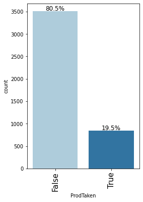

```python
labeled_barplot(df, "ProdTaken", perc=True)
```

- Most customers did not purchase a package (80.5%)

### Observations on Age

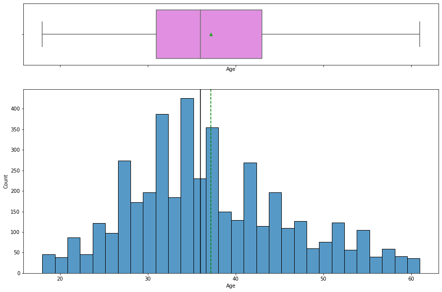

```python
histogram_boxplot(df,"Age")
```

- the distribution of Age is slightly right skewed
- there are no outliers in this variable
- We can see the third quartile is 43 which means 75% of customers have an Age under 43

### Observations on TypeofContact

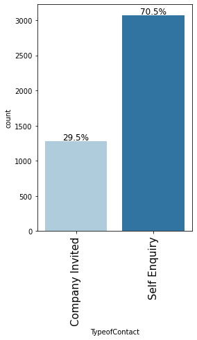

```python
labeled_barplot(df, "TypeofContact", perc=True)
```

- Majority of Customers came through Self Enquiry(70.5%)

### Observations on CityTier

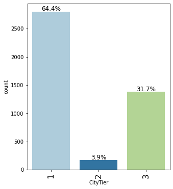

```python
labeled_barplot(df, "CityTier", perc=True)
```

### Observations on DurationOfPitch

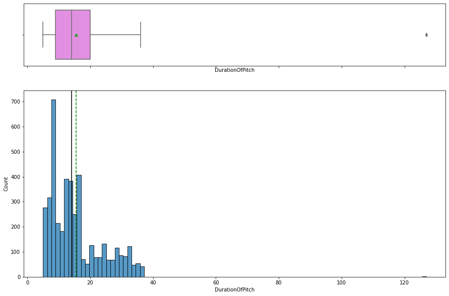

```python
histogram_boxplot(df,"DurationOfPitch")
```

- the distribution of DurationOfPitch is right skewed
- there are very few outliers but at a very high value
- We can see the third quartile is 20 which means 75% of customers had a pitch of 20 minutes

### Observations on Occupation

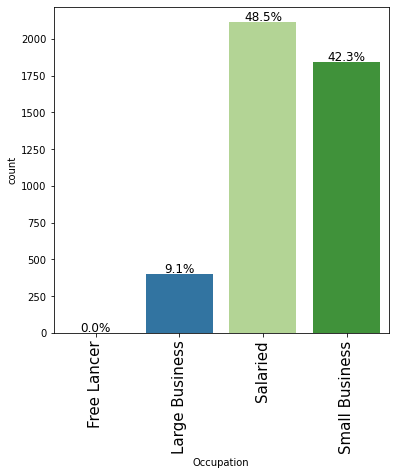

```python
labeled_barplot(df, "Occupation", perc=True)
```

- Most customers are salaried (48.5%)
- The second largest group of customers are employed by a small business (42.3%)
- The third largest category of customers are emplyed by a large business (9.1%)
- The smallest group of customers is almost nonexistent, they are Free lancers(approx <0.1%)

### Observations on Gender

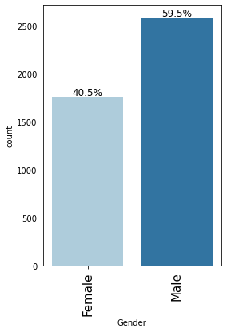

```python
labeled_barplot(df, "Gender", perc=True)
```

- Most customers are Male (59.5%)

### Observations on NumberOfPersonVisiting

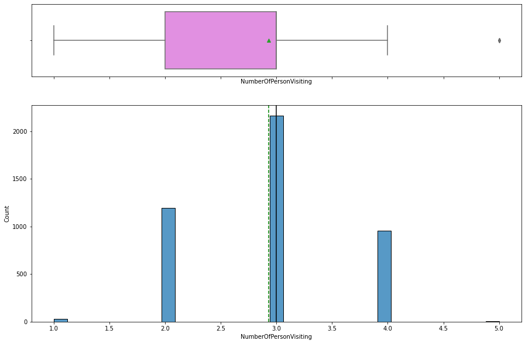

```python
histogram_boxplot(df,"NumberOfPersonVisiting")
```

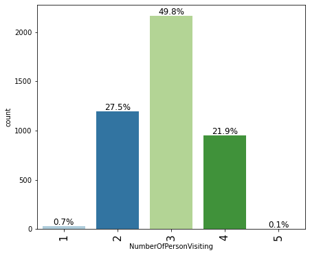

```python
labeled_barplot(df, "NumberOfPersonVisiting", perc=True)
```

- Variable is in discrete numbers because it is representative of number of people
- The NumberOfPersonVisiting distribution is left skewed.
- Small percentage of outliers
- Most customers travel with 3 people (49.8%) followed by 2 people (27.5%) and 4 people(21.9%) and 1 person (0.7%)
- Least amount of customers travel with 5 people(0.1%)

### Observations on NumberOfFollowups

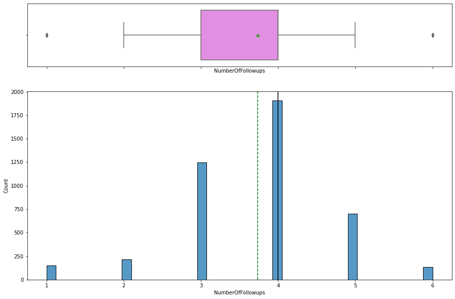

```python
histogram_boxplot(df,"NumberOfFollowups")
```

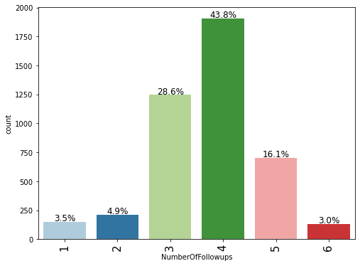

```python
labeled_barplot(df, "NumberOfFollowups", perc=True)
```

- Variable is in discrete numbers because it is representative of number of followups.
- The NumberOfFollowups distribution is left skewed.
- Small percentage of outliers, customers with 1 follow up and 6 follow ups.
- Most customers get 4 followups (43.8%) followed by 3 followups (28.6%), 5 followups (16.1%) and 2 followups (4.9%)
- Least amount of customers have 6 follow ups(3.0%)

### Observations on ProductPitched

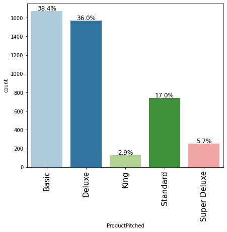

```python
labeled_barplot(df, "ProductPitched", perc=True)
```

- Most customers are pitched on the basic product (38.4%) closely followed by the deluxe product (36.0%), then the standard product (17.0) and the super deluxe product (5.7%).
- Least amount of customers are pitched the King product (2.9%)

### Observations on PreferredPropertyStar

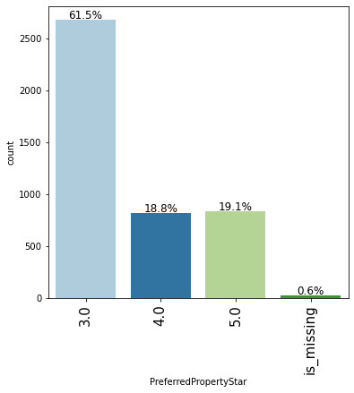

```python
labeled_barplot(df, "PreferredPropertyStar", perc=True)
```

- Most customers perfer a 3 star property (61.5%) followed by 5 star (19.1%) and 4 people(18.8%)
- Least amount of customers have no value/preferrence (0.6%)

### Observations on MaritalStatus

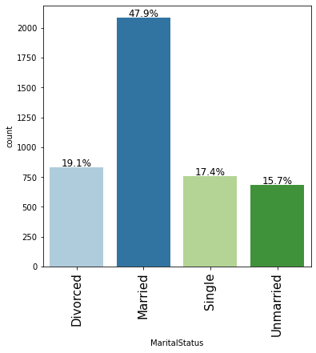

```python
labeled_barplot(df, "MaritalStatus", perc=True)
```

- Most customers are married (47.9%) followed by divorced (19.1%) and single (17.4%).
- Least amount of customers are unmarried (15.7%)

### Observations on NumberOfTrips

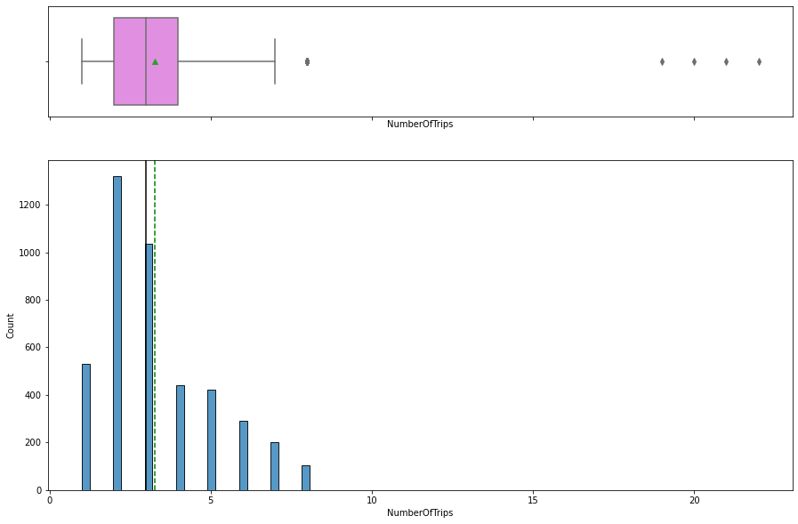

```python
histogram_boxplot(df,"NumberOfTrips")
```

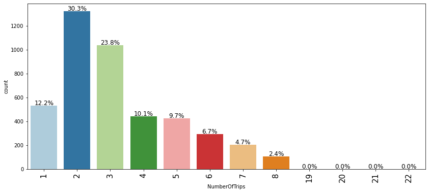

```python
labeled_barplot(df, "NumberOfTrips", perc=True)
```

- Variable is in discrete numbers because it is representative of number of trips.
- The NumberOfTrips distribution is slightly right skewed.
- Small percentage of outliers starting from 8+ trips
- Most customers go on 2 trips (30.3%) followed by 3 trips (23.8%), 1 trip (12.2%), 4 trips (10.1%), and 5 trips (9.7%)
- Least amount of customers go on 8-22 trips follow ups (2.4%)

### Observations on Passport

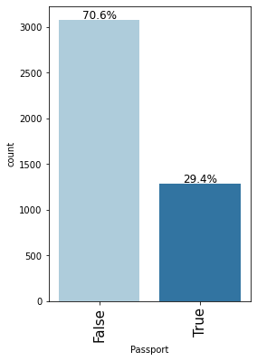

```python
labeled_barplot(df, "Passport", perc=True)
```

- Most customers do not have a passport (70.6%)

### Observations on PitchSatisfactionScore

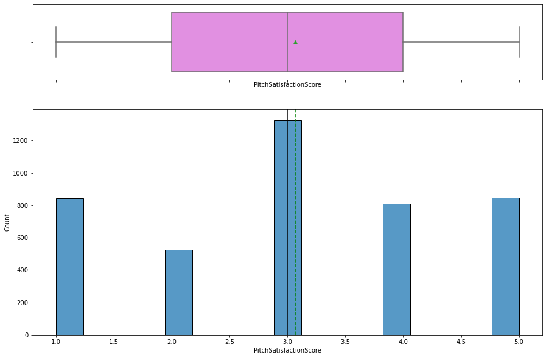

```python
histogram_boxplot(df,"PitchSatisfactionScore")
```

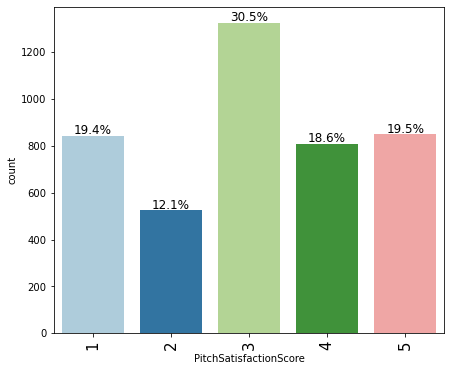

```python
labeled_barplot(df, "PitchSatisfactionScore", perc=True)
```

### Observations on OwnCar

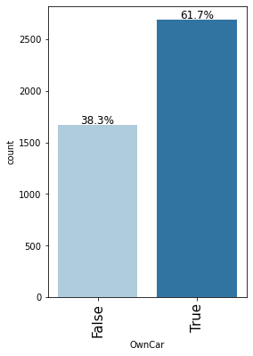

```python
labeled_barplot(df, "OwnCar", perc=True)
```

- Most customers own a car (61.7%)

### Observations on NumberOfChildrenVisiting

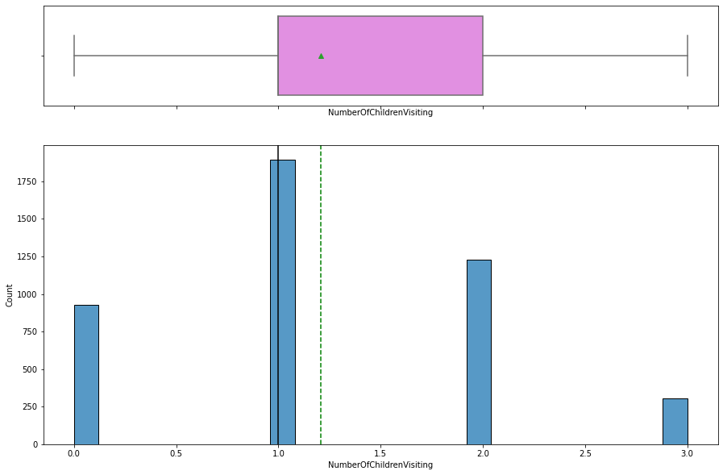

```python
histogram_boxplot(df,"NumberOfChildrenVisiting")
```

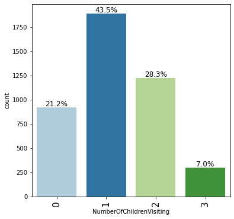

```python
labeled_barplot(df, "NumberOfChildrenVisiting", perc=True)
```

### Observations on Designation

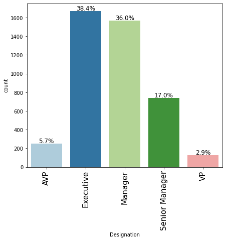

```python
labeled_barplot(df, "Designation", perc=True)
```

- Most customers are Executives (38.4%) followed by Managers (36.0%), Senior Managers (17.0%) and AVP's (5.7%).
- Least amount of customers are VP's (2.9%)

### Observations on MonthlyIncome

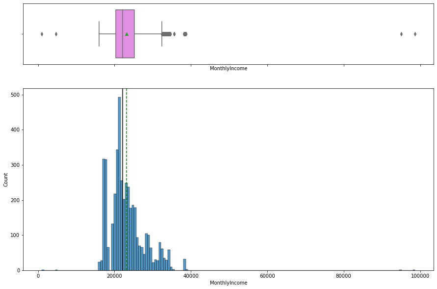

```python
histogram_boxplot(df,"MonthlyIncome")
```

- the distribution of MonthlyIncome is right skewed.
- there are many outliers in this variable.
- We can see the third quartile is 25221 which means 75% of customers have make under 25221 dollars.

## Bivariate Analysis

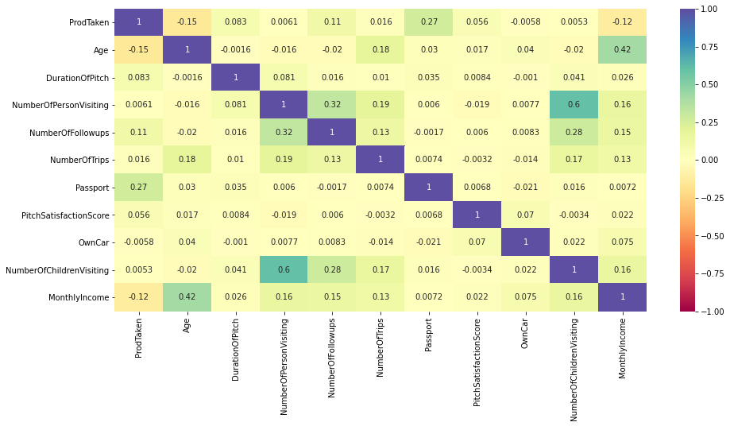

```python
plt.figure(figsize=(15, 7))
sns.heatmap(df.corr(), annot=True, vmin=-1, vmax=1, cmap="Spectral")
plt.show()
```

- Highest correlation between NumberOfPersonVisiting and NumberOfChildrenVisiting.
- MonthlyIncome moderately positively correlated with Age and less but still positively correlated with NumberOfPersonVisiting, NumberOfFollowups, NumberOfTrips and NumberOfChildren
- ProductTaken moderately positively correlated with Passport and less but still positivelu corellated with NumberOfFollowups
- NumberOfFollowups postiviely correlated with NumberOfPersonVisiting and less but still positively corellated with Number ofTrips and ProdTaken

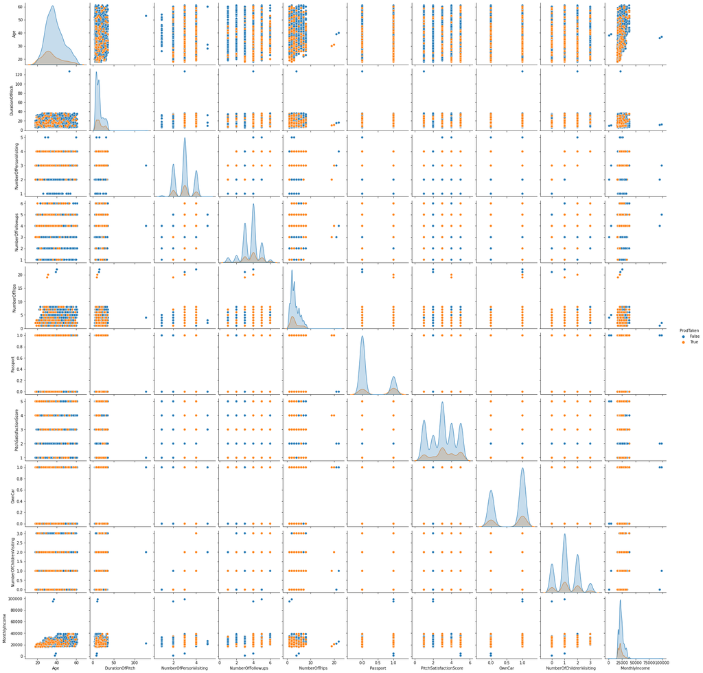

```python
sns.pairplot(data=df, hue="ProdTaken")
plt.show()
```